# 1. Librerías y dataset

```python
import pandas as pd
import numpy as np
import matplotlib.pyplot as plt
import seaborn as sns
from sklearn.preprocessing import StandardScaler
from sklearn.decomposition import PCA
from sklearn.cluster import KMeans
```

```python
ruta = r'C:\Users\ANDRES\Desktop\PROYECTOS\pinguinos'
archivo = r'\penguins.csv'
```

```python
df = pd.read_csv(ruta + archivo, index_col = 0)
```

```python
df.head(1)
```

|  | species | island | bill_length_mm | bill_depth_mm | flipper_length_mm | body_mass_g | sex | year |
| --- | --- | --- | --- | --- | --- | --- | --- | --- |
| 1 | Adelie | Torgersen | 39.1 | 18.7 | 181.0 | 3750.0 | male | 2007 |

```python
df.shape
## 344 filas y 8 columnas
```

```
(344, 8)
```

### Traducción del nombre de las columnas

```python
df.rename(columns={'species': 'especies', 'island':'isla', 'bill_length_mm':'long_pico',
                   'bill_depth_mm':'profun_pico', 'flipper_length_mm':'long_aleta',
                   'body_mass_g':'masa', 'sex':'sexo', 'year':'año'}, inplace=True)
df.head(2)
```

|  | especies | isla | long_pico | profun_pico | long_aleta | masa | sexo | año |
| --- | --- | --- | --- | --- | --- | --- | --- | --- |
| 1 | Adelie | Torgersen | 39.1 | 18.7 | 181.0 | 3750.0 | male | 2007 |
| 2 | Adelie | Torgersen | 39.5 | 17.4 | 186.0 | 3800.0 | female | 2007 |

### Formato de columnas

```python
#df.select_dtypes('int')
#df.select_dtypes('object')
#df.select_dtypes('float')
```

### Valores nulos

##### Haciendo una revisión general, podemos ver que hay valores nulos en algunas columnas, específicamente los valores nulos por columna se relacionan a continuación:

```python
df.isna().sum()
```

```
especies        0
isla            0
long_pico       2
profun_pico     2
long_aleta      2
masa            2
sexo           11
año             0
dtype: int64
```

##### Vamos a revisar si los valores que corresponden a 2 valores nulos corresponden a los mismos registros

```python
df[df['long_pico'].isna()]
```

|  | especies | isla | long_pico | profun_pico | long_aleta | masa | sexo | año |
| --- | --- | --- | --- | --- | --- | --- | --- | --- |
| 4 | Adelie | Torgersen | NaN | NaN | NaN | NaN | NaN | 2007 |
| 272 | Gentoo | Biscoe | NaN | NaN | NaN | NaN | NaN | 2009 |

##### Efectivamente, los valores nulos corresponden a los mismos registros. Antes de tomar decisiones respecto a estos registros, veamos aquellos valores nulos correspondientes a la columna de `sexo`

```python
df[df['sexo'].isna()]
```

|  | especies | isla | long_pico | profun_pico | long_aleta | masa | sexo | año |
| --- | --- | --- | --- | --- | --- | --- | --- | --- |
| 4 | Adelie | Torgersen | NaN | NaN | NaN | NaN | NaN | 2007 |
| 9 | Adelie | Torgersen | 34.1 | 18.1 | 193.0 | 3475.0 | NaN | 2007 |
| 10 | Adelie | Torgersen | 42.0 | 20.2 | 190.0 | 4250.0 | NaN | 2007 |
| 11 | Adelie | Torgersen | 37.8 | 17.1 | 186.0 | 3300.0 | NaN | 2007 |
| 12 | Adelie | Torgersen | 37.8 | 17.3 | 180.0 | 3700.0 | NaN | 2007 |
| 48 | Adelie | Dream | 37.5 | 18.9 | 179.0 | 2975.0 | NaN | 2007 |
| 179 | Gentoo | Biscoe | 44.5 | 14.3 | 216.0 | 4100.0 | NaN | 2007 |
| 219 | Gentoo | Biscoe | 46.2 | 14.4 | 214.0 | 4650.0 | NaN | 2008 |
| 257 | Gentoo | Biscoe | 47.3 | 13.8 | 216.0 | 4725.0 | NaN | 2009 |
| 269 | Gentoo | Biscoe | 44.5 | 15.7 | 217.0 | 4875.0 | NaN | 2009 |
| 272 | Gentoo | Biscoe | NaN | NaN | NaN | NaN | NaN | 2009 |

##### Aquí se puede apreciar que los dos registros nulos en las columnas numéricas están incluídos en los valores nulos del sexo. Por tanto, se toma la decisión de prescindir de los dos registros numéricos y continuar con el dataset con los nueve registros con `sexo` nulo.

```python
df = df.drop( df[df['long_pico'].isna()].index )
# Aquí ya eliminamos los dos registros de valores numéricos nulos
```

```python
df.shape
```

```
(342, 8)
```

# 2. Análisis exploratorio de datos

```python
color_especie = ['#f19601', '#f21f26', '#73b295'] # Amarillo, rojo, verde
```

## 2.1. Distribución de las especies

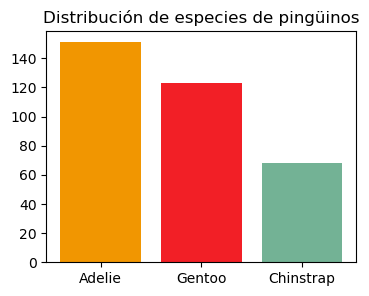

```python
plt.figure(figsize=(4, 3))
plt.bar(df['especies'].unique(), df['especies'].value_counts(), color=color_especie)
plt.title('Distribución de especies de pingüinos')
plt.show()
```

```python
pd.DataFrame(df.groupby(['especies', 'isla'])['especies'].count())
```

| especies | isla | especies |
| --- | --- | --- |
| Adelie | Biscoe | 44 |
|  | Dream | 56 |
|  | Torgersen | 51 |
| Chinstrap | Dream | 68 |
| Gentoo | Biscoe | 123 |

##### Veamos cómo es la distribución de machos y hembras en cada especie

```python
df.groupby(['especies', 'sexo'])['especies'].count()
```

```
especies   sexo
Adelie     female    73
           male      73
Chinstrap  female    34
           male      34
Gentoo     female    58
           male      61
Name: especies, dtype: int64
```

##### Aquí notamos una incongruencia, ya que la suma de pingüinos **Adelie** cuando filtro por islas es de 151, pero al filtrar por sexo es de 146, una diferencia de 5. Esto sucede porque al contar por sexo hay algunos datos nulos que impiden que nos den los valores iguales. A continuación, vamos a probarlo

```python
print(df['sexo'].isna().sum(), df['isla'].isna().sum())
# Aquí vemos que por sexo hay 9 valores nulos.
```

```
9 0
```

##### Hagamos un gráfico de barras con la cantidad de cada sexo agrupadas por especie

```python
conteo = df.groupby(['especies', 'sexo']).size().unstack()
# Hacemos la agrupación pero usamos .unstack() para separar las columnas adecuadamente
#conteo # Ahí puede ver que es un dataframe bien definido
```

```python
especies = conteo.index
color_sexo = ['#268fbe', '#a9f04d'] # Macho (azul), hembra (verde)
```

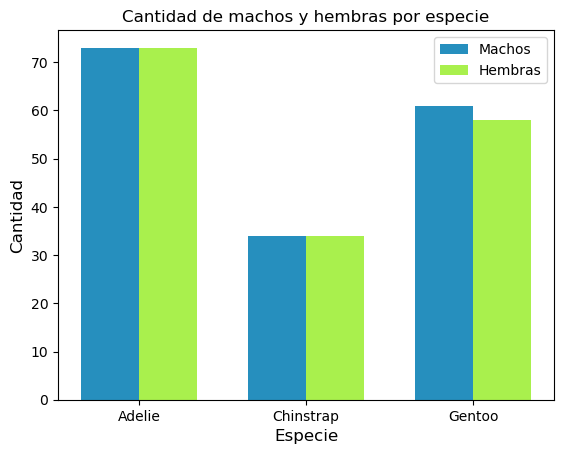

```python
x = np.arange(len(especies)) # Se hace como arange para que itere sobre los valores
ancho = 0.35

plt.bar(x - ancho/2, conteo['male'], width=ancho, label='Machos', color='#268fbe')
plt.bar(x + ancho/2, conteo['female'], width=ancho, label='Hembras', color = '#a9f04d')

plt.xticks(x, especies)
plt.xlabel('Especie', size=12)
plt.ylabel('Cantidad', size=12)
plt.title('Cantidad de machos y hembras por especie')
plt.legend()
plt.show()
```

##### La especie **Chinstrap** es la que habita más al norte (isla Dream), la especie **Gentoo** (isla Biscoe) es la que vive más al sur y la **Adelie** se distribuye en toda la región.

```python
df['año'].value_counts().sort_values(ascending=True)
```

```
año
2007    109
2008    114
2009    119
Name: count, dtype: int64
```

```python
df.tail(2)
```

|  | especies | isla | long_pico | profun_pico | long_aleta | masa | sexo | año |
| --- | --- | --- | --- | --- | --- | --- | --- | --- |
| 343 | Chinstrap | Dream | 50.8 | 19.0 | 210.0 | 4100.0 | male | 2009 |
| 344 | Chinstrap | Dream | 50.2 | 18.7 | 198.0 | 3775.0 | female | 2009 |

## 2.2. Correlación entre variables numéricas

##### Al revisar la columna de año vemos que esta variable no tiene un impacto significativo en el dataset, pues no es fácil determinar su relevenacia con lo que se conoce de la toma de los datos. Por esta razón, vamos a hacer el análisis entre las variables numéricas sin tenerla en cuenta.

```python
df.select_dtypes('float').head(2)
```

|  | long_pico | profun_pico | long_aleta | masa |
| --- | --- | --- | --- | --- |
| 1 | 39.1 | 18.7 | 181.0 | 3750.0 |
| 2 | 39.5 | 17.4 | 186.0 | 3800.0 |

```python
corr = df.select_dtypes('float').corr()
corr
```

|  | long_pico | profun_pico | long_aleta | masa |
| --- | --- | --- | --- | --- |
| long_pico | 1.000000 | -0.235053 | 0.656181 | 0.595110 |
| profun_pico | -0.235053 | 1.000000 | -0.583851 | -0.471916 |
| long_aleta | 0.656181 | -0.583851 | 1.000000 | 0.871202 |
| masa | 0.595110 | -0.471916 | 0.871202 | 1.000000 |

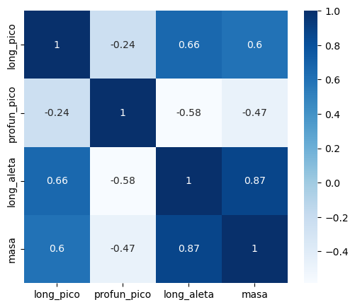

```python
plt.figure(figsize=(6,5))
sns.heatmap(corr, annot=True, cmap='Blues')
plt.show()
```

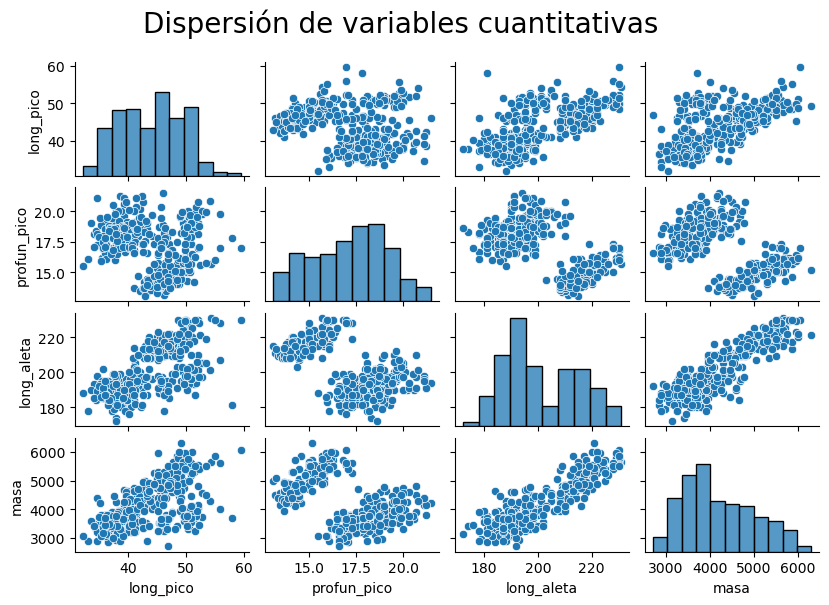

```python
sns.pairplot(df.select_dtypes('float'),
        height=1.4,     # tamaño de cada subplot (en pulgadas)
        aspect=1.5     # relación ancho / alto
)
plt.title('Dispersión de variables cuantitativas', size=20, x=-1.4, y=4.5)
plt.show()
```

##### En el heatmap vemos que hay variables correlacionadas de forma negativa, sin embargo, al realizar la dispersión, al parecer se forman grupos que se correlacionan positivamente. Es el caso de `masa` con `pofun_pico`, `long_aleta` con `profun_pico` y finalmente, `profun_pico` con `long_pico`. Para encontrar una explicación a este hecho, probablemente debemos hacer una segmentación de los datos y quizás así se pueda encontrar una explicación a este hecho.

## 2.2.1 `profun_pico` vs `long_pico`

##### Esto podríamos hacerlo con `groupby` o con filtros (máscaras). Con filtros, debería hacerse un filtro para cada especie, al ser solo tres especies solo debemos hacer tres filtros, lo cual no toma mucho tiempo.

##### Para realizarlo con `groupby` debemos generar un objeto `grupos = df.groupby('especie')` que es iterable

### Filtros

```python
# Adelie, Gentoo, Chinstrap

df_A = df[df['especies'] == 'Adelie']
df_C = df[df['especies'] == 'Chinstrap']
df_G = df[df['especies'] == 'Gentoo']
```

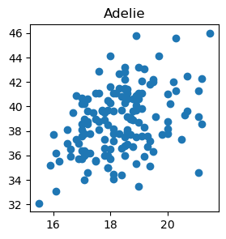

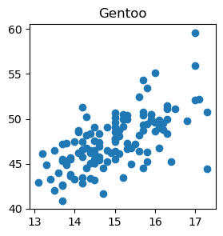

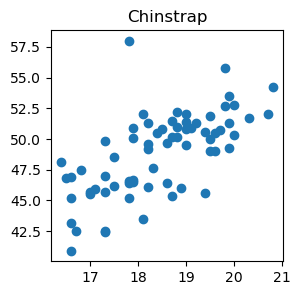

```python
plt.figure(figsize=(3,3))
plt.scatter(df_A['profun_pico'], df_A['long_pico'])
plt.title('Adelie')
plt.show()

plt.figure(figsize=(3,3))
plt.scatter(df_G['profun_pico'], df_G['long_pico'])
plt.title('Gentoo')
plt.show()

plt.figure(figsize=(3,3))
plt.scatter(df_C['profun_pico'], df_C['long_pico'])
plt.title('Chinstrap')
plt.show()
```

##### Aquí podemos evidenciar que al separar por esepecies, las correlaciones parecen positivas. Ahora vamos a unificar todos en un mismo gráfico, separando por `color_especie`

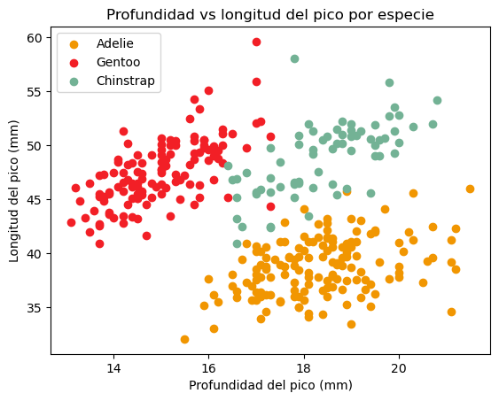

```python
# ['#f19601', '#f21f26', '#73b295'] # Adelie (Amarillo), Gentoo (rojo), Chinstrap (verde)
plt.scatter(df_A['profun_pico'], df_A['long_pico'], color=color_especie[0], label='Adelie')
plt.scatter(df_G['profun_pico'], df_G['long_pico'], color=color_especie[1], label='Gentoo')
plt.scatter(df_C['profun_pico'], df_C['long_pico'], color=color_especie[2], label='Chinstrap')
plt.legend()
plt.title('Profundidad vs longitud del pico por especie')
plt.xlabel('Profundidad del pico (mm)')
plt.ylabel('Longitud del pico (mm)')

plt.show()
```

### Group by

```python
df.groupby('especies') # Este es un objeto conformado por tuplas de la forma (especie, dataframe[especie]
```

```
<pandas.core.groupby.generic.DataFrameGroupBy object at 0x0000015B929FE650>
```

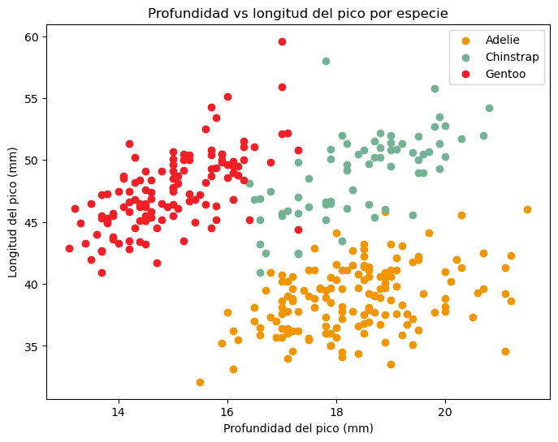

```python
map_color_especie = {'Adelie':'#f19601', 'Gentoo':'#f21f26', 'Chinstrap':'#73b295'}

plt.figure(figsize=(8, 6))
for especie, sub in df.groupby('especies'):
    plt.scatter(
        sub['profun_pico'],
        sub['long_pico'],
        label=especie,
        color=map_color_especie[especie],
        alpha=1
    )

plt.legend()
plt.title('Profundidad vs longitud del pico por especie')
plt.xlabel('Profundidad del pico (mm)')
plt.ylabel('Longitud del pico (mm)')
plt.show()
```

## 2.2.2 `long_aleta` vs `profun_pico`

##### Con estas varibales pasa algo similar. En este caso vamos a separar por especie y por sexo.

### Por especie

##### En este caso vamos a agregar líneas de tendencia, para esto vamos a hacer uso de la funcion `np.polyfit(x, y, n)` donde `n` es el grado del polinomio y nos retorna `n+1` coeficientes que debemos guardar para poder graficar el polinomio.

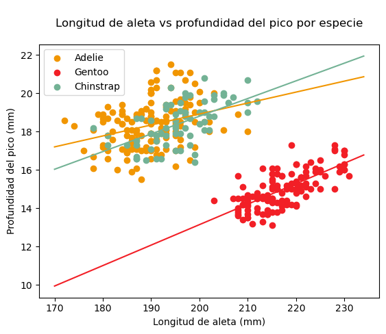

```python
plt.scatter(df_A['long_aleta'], df_A['profun_pico'], label='Adelie', color=color_especie[0])
plt.scatter(df_G['long_aleta'], df_G['profun_pico'], label='Gentoo', color=color_especie[1])
plt.scatter(df_C['long_aleta'], df_C['profun_pico'], label='Chinstrap', color=color_especie[2])
plt.title('\nLongitud de aleta vs profundidad del pico por especie\n', size=12)
plt.xlabel('Longitud de aleta (mm)')
plt.ylabel('Profundidad del pico (mm)')

m_A, b_A = np.polyfit(df_A['long_aleta'], df_A['profun_pico'], 1)
x = np.arange(170, 235, 2)
y = m_A*x + b_A
plt.plot(x,y, color=color_especie[0])

m_G, b_G = np.polyfit(df_G['long_aleta'], df_G['profun_pico'], 1)
x = np.arange(170, 235, 2)
y = m_G*x + b_G
plt.plot(x,y, color=color_especie[1])

m_C, b_C = np.polyfit(df_C['long_aleta'], df_C['profun_pico'], 1)
x = np.arange(170, 235, 2)
y = m_C*x + b_C
plt.plot(x,y, color=color_especie[2])

plt.legend()
plt.show()
```

### Por sexo

##### Para este caso y como reto, vamos a realizar el gráfico con `groupby`

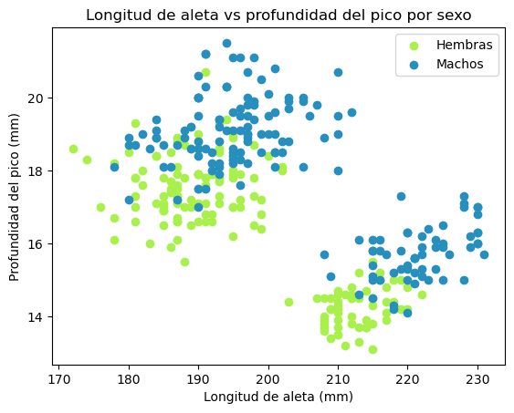

```python
#color_sexo = ['#268fbe', '#a9f04d'] # Macho (azul), hembra (verde)
# Mapeo explícito
map_color_sexo = {'male': color_sexo[0], 'female': color_sexo[1]}
etiqueta_sexo = {'male':'Machos', 'female':'Hembras'}

sexos = df.groupby('sexo')
for sexo, sub_df in df.groupby('sexo'):
    plt.scatter(sub_df['long_aleta'], sub_df['profun_pico'], label=etiqueta_sexo[sexo], color = map_color_sexo[sexo])

plt.title('Longitud de aleta vs profundidad del pico por sexo', size=12)
plt.xlabel('Longitud de aleta (mm)')
plt.ylabel('Profundidad del pico (mm)')
plt.legend()
plt.show()
```

## 2.2.3 `masa` vs `profun_pico`

##### Tal como en la parte anterior, vamos a hacer la separación por `sexo` y por `especie`.

### Por sexo

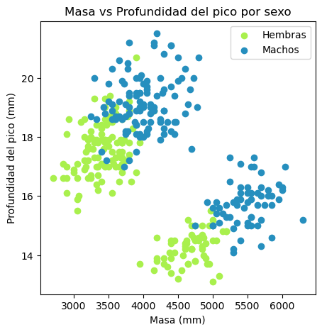

```python
plt.figure(figsize=(5,5))
for sexo, sub_df_sexo in df.groupby('sexo'):
    plt.scatter(sub_df_sexo['masa'], sub_df_sexo['profun_pico'], label=etiqueta_sexo[sexo], color=map_color_sexo[sexo])

plt.title('Masa vs Profundidad del pico por sexo', size=12)
plt.xlabel('Masa (mm)')
plt.ylabel('Profundidad del pico (mm)')
plt.legend()
plt.show()
```

### Por especie

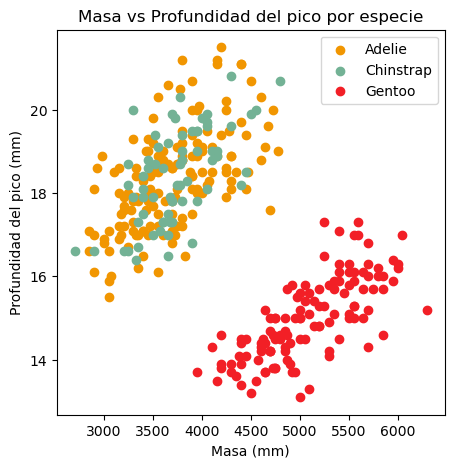

```python
#map_color_especie = {'Adelie':'#f19601', 'Gentoo':'#f21f26', 'Chinstrap':'#73b295'}
plt.figure(figsize=(5,5))
for especie, sub_df_especie in df.groupby('especies'):
    plt.scatter(sub_df_especie['masa'], sub_df_especie['profun_pico'], label=especie, color=map_color_especie[especie])

plt.title('Masa vs Profundidad del pico por especie', size=12)
plt.xlabel('Masa (mm)')
plt.ylabel('Profundidad del pico (mm)')
plt.legend()
plt.show()
```

## 2.2.4 `masa` vs `long_aleta`

##### Estas dos variables presentan una correlación del 0.87. Sin embargo, así como se hizo con las otras variables es necesario discriminar por sexo y por especie para evitar llegar a conlusiones apresuradas.

### Por especie

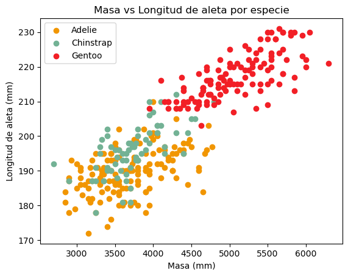

```python
for especie, sub_df_especie in df.groupby('especies'):
    plt.scatter(sub_df_especie['masa'], sub_df_especie['long_aleta'], label=especie, color=map_color_especie[especie])

plt.legend()
plt.title('Masa vs Longitud de aleta por especie', size=12)
plt.xlabel('Masa (mm)')
plt.ylabel('Longitud de aleta (mm)')
plt.show()
```

##### Sí se nota una correlación positiva cuando se filtra por especie

### Por sexo

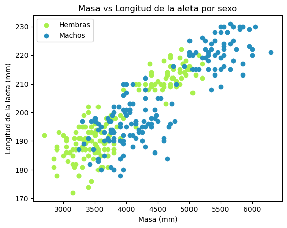

```python
for sexo, sub_df_sexo in df.groupby('sexo'):
    plt.scatter(sub_df_sexo['masa'], sub_df_sexo['long_aleta'], label=etiqueta_sexo[sexo], color=map_color_sexo[sexo])

plt.legend()
plt.title('Masa vs Longitud de la aleta por sexo', size=12)
plt.xlabel('Masa (mm)')
plt.ylabel('Longitud de la laeta (mm)')
plt.show()
```

##### Aquí podemos apreciar que las nubes de puntos muestran que los machos registran un valor mayor en cada variable.

# 3. Análisis de componentes principales

##### Este análisis lo haremos sobre las variables numéricas. Trataremos de identificar características de los elementos y luego realizaremos una agrupación vía *K_means* para ver si los resultados coinciden con las especies del dataset.

## 3.1 Escalamiento y varianza explicada

### Escalamos los datos

```python
df_num = df.select_dtypes('float')
X_scaled = StandardScaler().fit_transform(df_num)
X_scaled = pd.DataFrame(X_scaled, columns = df_num.columns, index=df.index)
```

```python
# Es recomendable usar pca = PCA()
pca = PCA()
X_pca = pca.fit_transform(X_scaled)
```

### Varianza explicada y acumulada

```python
var_exp = pca.explained_variance_ratio_
var_exp_acum = np.cumsum(var_exp)
var_exp_acum
```

```
array([0.68843878, 0.88156797, 0.97287695, 1.        ])
```

##### Con una variable se explica el 68% de la varianza, con dos el 88%, con tres el 97% y con las cuatro el 100%. Dos variables pueden ser una buena variabilidad, pues supera el 80%, lo cual es un buen indicador.

```python
pca_summary = pd.DataFrame({
    'Componente':range(1, len(var_exp) + 1),
    'Varianza explicada': var_exp,
    'Varianza explicada acumulada': var_exp_acum})
pca_summary
```

|  | Componente | Varianza explicada | Varianza explicada acumulada |
| --- | --- | --- | --- |
| 0 | 1 | 0.688439 | 0.688439 |
| 1 | 2 | 0.193129 | 0.881568 |
| 2 | 3 | 0.091309 | 0.972877 |
| 3 | 4 | 0.027123 | 1.000000 |

### Gráfica de PCA acumulada

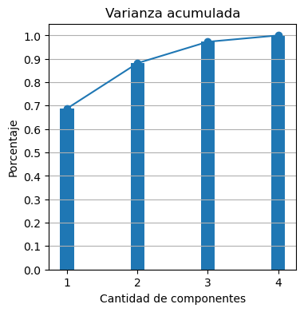

```python
x = np.arange(1, len(var_exp) + 1)
x = list(x)

plt.figure(figsize=(4,4))
plt.plot(x, var_exp_acum, marker='o')
plt.bar(x, var_exp_acum, width=0.2)

plt.title('Varianza acumulada', size=12)
plt.xlabel('Cantidad de componentes')
plt.ylabel('Porcentaje')
plt.xticks(x)
plt.yticks(np.arange(0, 1.1, 0.1))
plt.grid(axis='y')
plt.show()
```

## 3.2 Coeficientes (loadings)

##### Cuando hacemos un proceso de PCA estamos transformando el espacio, por tal motivo, los vectores de la base terminan siendo una combinación lineal de las variables originales. Los *loadings* son los coeficientes de dicha combinación y podemos encontrarlos así:

```python
loadings = pd.DataFrame(pca.components_, columns=df_num.columns, index=[f'PC{i+1}' for i in range(pca.components_.shape[0]) ])
loadings
```

|  | long_pico | profun_pico | long_aleta | masa |
| --- | --- | --- | --- | --- |
| PC1 | 0.455250 | -0.400335 | 0.576013 | 0.548350 |
| PC2 | 0.597031 | 0.797767 | 0.002282 | 0.084363 |
| PC3 | 0.644301 | -0.418427 | -0.232084 | -0.596600 |
| PC4 | -0.145523 | 0.167986 | 0.783799 | -0.579882 |

```python
loadings.iloc[1]
```

```
long_pico      0.597031
profun_pico    0.797767
long_aleta     0.002282
masa           0.084363
Name: PC2, dtype: float64
```

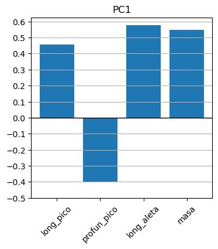

```python
coef_pc1 = pca.components_[0]
coef_pc2 = pca.components_[1]
x = range(len(df_num.columns))

plt.figure(figsize=(4,4))
plt.bar(x, coef_pc1)
plt.axhline(0, color='black', linewidth=1)
plt.xticks(x, df_num.columns, rotation=45)
plt.yticks(np.arange(-0.5, 0.61, 0.1))
plt.title('PC1')
plt.grid(axis='y')

plt.show()
```

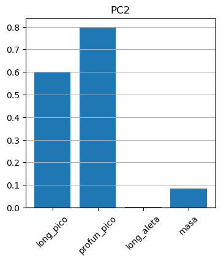

```python
plt.figure(figsize=(4,4))
plt.bar(x, coef_pc2)
plt.axhline(0, color='black', linewidth=1)
plt.xticks(x, df_num.columns, rotation=45)
plt.yticks(np.arange(0, 0.81, 0.1))
plt.title('PC2')
plt.grid(axis='y')
```

### Interpretación de los coeficientes

##### Con esto podemos ver que un valor grande de `profun_pico` indica un pico más robusto, es decir, más ancho en su base.

#### PC1

##### Los coeficientes grandes en **PC1** para las variables de `long_pico`, `long_aleta` y `masa` indican pinguinos grandes y el valor negativo de profun_pico nos muestra que si el valor de **PC1** es grande, el pico es poco robusto, es decir, picos delgados o de base pequeña comparada con su longitud.

##### Por otra parte, un valor pequeño (negativo) de **PC1** se relaciona con pinguinos de menor tamaño y pico más robusto

##### Finalmente, valores cercanos a cero de **PC1** muestra un balance entre el tamaño del pinguino y la robustez de su pico, es decir, son de un tamaño menor y con pico robusto.

#### PC2

##### Esta componente está definida prácticamente por el pico, especialmente por la profundidad o robustez del mismo. Si el valor de **PC2** es grande indica que el pingüino tiene un pico grande en comparación con su tamaño, un pico robusto pero también largo.

##### Si el valor de **PC2** es cercano a cero, indica que el pico es poco robusto y tiende a ser corto. Note que la loongitud de la aleta no interviene mucho en este valor.

##### Finalmente, valores negativos de **PC2** se relacionan con pingüinos con un pico más delgado y corto.

## 3.3 Plano proyectivo PC1 vs PC2

##### Para realizar este plano debemos hacer uso de la información contenida en `X_pca`

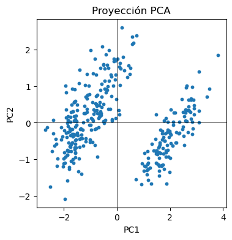

```python
plt.figure(figsize=(4,4))
plt.scatter(X_pca[:,0], X_pca[:,1], s=10)
plt.xlabel('PC1')
plt.ylabel('PC2')
plt.title('Proyección PCA', size=12)
plt.axhline(0, color='black', linewidth=0.5)
plt.axvline(0, color='black', linewidth=0.5)

plt.show()
```

##### Ahora vamos a incluirle los extremos de PC1 y PC2 para interpretar mejor el gráfico.

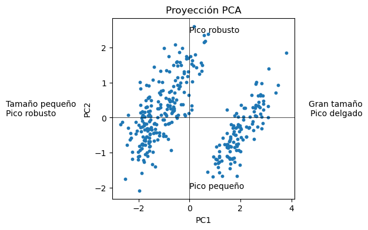

```python
# Vamos a identificar los extremos en cada eje
pc1_min, pc1_max = X_pca[:, 0].min(), X_pca[:, 0].max()
pc2_min, pc2_max = X_pca[:, 1].min(), X_pca[:, 1].max()

plt.figure(figsize=(4,4))
plt.scatter(X_pca[:,0], X_pca[:,1], s=10)
plt.xlabel('PC1')
plt.ylabel('PC2')

# Textos extremos PC1
plt.text(pc1_max + 3, 0, 'Gran tamaño\nPico delgado', ha='right', va='bottom')
plt.text(pc1_min -4.5, 0, 'Tamaño pequeño\nPico robusto', ha='left', va='bottom')

# Textos extremos PC2
plt.text(0, pc2_max, 'Pico robusto', ha='left', va='top')
plt.text(0, pc2_min, 'Pico pequeño', ha='left', va='bottom')

plt.title('Proyección PCA', size=12)
plt.axhline(0, color='black', linewidth=0.5)
plt.axvline(0, color='black', linewidth=0.5)

plt.show()
```

##### Recordedmos que cada fila de `X_pca` es una matriz, donde cada fila representa los coeficientes para cada registro. Como nosotros solo estamos analizando **PC1** y **PC2**, podemos agregar estas columnas al `df` original

```python
#Agregamps las nuevas columnas
df['PC1'] = X_pca[:, 0]
df['PC2'] = X_pca[:, 1]
```

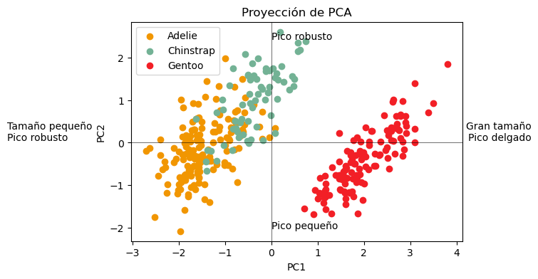

```python
pc1_min, pc1_max = df['PC1'].min(), df['PC2'].max()
pc2_min, pc2_max = df['PC2'].min(), df['PC2'].max()

plt.figure(figsize=(6,4))
for especie, sub_df_especie in df.groupby('especies'):
    plt.scatter(sub_df_especie['PC1'], sub_df_especie['PC2'], label=especie, color=map_color_especie[especie])

plt.title('Proyección de PCA')
plt.xlabel('PC1')
plt.ylabel('PC2')
plt.legend()

# Textos extremos PC1
plt.text(pc1_max + 3, 0, 'Gran tamaño\nPico delgado', ha='right', va='bottom')
plt.text(pc1_min -3, 0, 'Tamaño pequeño\nPico robusto', ha='left', va='bottom')

# Textos extremos PC2
plt.text(0, pc2_max, 'Pico robusto', ha='left', va='top')
plt.text(0, pc2_min, 'Pico pequeño', ha='left', va='bottom')

plt.axhline(0, color='black', linewidth=0.4)
plt.axvline(0, color='black', linewidth=0.4)
plt.show()
```

### Conclusión

##### Los pingüinos *Gentoo* son los más grandes con picos delgados. Morfológicamente, los *Chinstrap* se parecen más a los *Adelie* en cuanto a tamaño de su cuerpo y de su pico. Sin embargo, el pico más robusto pertenece a los *Adelie*.

##### En todas las especies, los machos tienen a ser un poco más grandes que las hembras.

# 4. Clustering

##### Para hacer el cluster vamos a hacer uso del algoritmo *K-Means*. Haremos el proceso con *K=3* para tratar de comprobar si podemos encontrar las especies. Para esto debemos importar ciertas librerías: De `sklearn.cluster` importar `KMeans`.

```python
# Vamos a trabajar sobre X_scaled, que contiene el escalamiento de las variables originales (sin PCA)

kmeans = KMeans(n_clusters = 3, random_state=42) # random_state es para poder hacer réplicas
clusters = kmeans.fit_predict(X_scaled)
```

```python
df['cluster'] = clusters
```

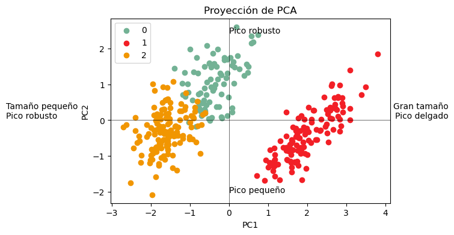

```python
plt.figure(figsize=(6,4))
for cluster, sub_df_clus in df.groupby('cluster'):
    plt.scatter(sub_df_clus['PC1'], sub_df_clus['PC2'], label=cluster, color=['#73b295', '#f21f26','#f19601'][cluster])

plt.title('Proyección de PCA')
plt.xlabel('PC1')
plt.ylabel('PC2')
plt.legend()

# Textos extremos PC1
plt.text(pc1_max + 3, 0, 'Gran tamaño\nPico delgado', ha='right', va='bottom')
plt.text(pc1_min -3, 0, 'Tamaño pequeño\nPico robusto', ha='left', va='bottom')

# Textos extremos PC2
plt.text(0, pc2_max, 'Pico robusto', ha='left', va='top')
plt.text(0, pc2_min, 'Pico pequeño', ha='left', va='bottom')

plt.axhline(0, color='black', linewidth=0.4)
plt.axvline(0, color='black', linewidth=0.4)

plt.legend()
plt.show()
```

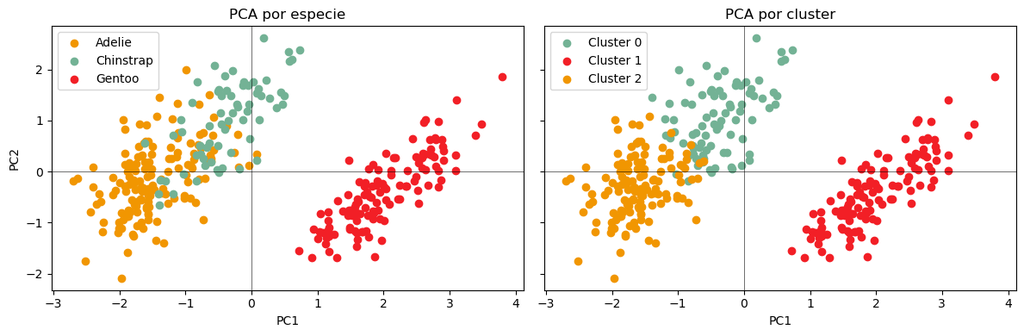

```python
fig, ax = plt.subplots(1, 2, figsize=(12, 4), sharex=True, sharey=True)

# ===== Gráfico 1: PCA por especie =====
for especie, sub_df_especie in df.groupby('especies'):
    ax[0].scatter(
        sub_df_especie['PC1'],
        sub_df_especie['PC2'],
        label=especie,
        color=map_color_especie[especie]
    )

ax[0].axhline(0, color='black', linewidth=0.4)
ax[0].axvline(0, color='black', linewidth=0.4)
ax[0].set_title('PCA por especie')
ax[0].set_xlabel('PC1')
ax[0].set_ylabel('PC2')
ax[0].legend()

# ===== Gráfico 2: PCA por cluster =====
colores_cluster = ['#73b295', '#f21f26', '#f19601']

for cluster, sub_df_clus in df.groupby('cluster'):
    ax[1].scatter(
        sub_df_clus['PC1'],
        sub_df_clus['PC2'],
        label=f'Cluster {cluster}',
        color=colores_cluster[cluster]
    )

ax[1].axhline(0, color='black', linewidth=0.4)
ax[1].axvline(0, color='black', linewidth=0.4)
ax[1].set_title('PCA por cluster')
ax[1].set_xlabel('PC1')
ax[1].legend()

plt.tight_layout()
plt.show()
```

### Conclusión

##### Podemos ver que hay cierta coincidencia entre los valores obtenidos con el **PCA** en el plano proyectivo y las etiquetas dadas por el cluster. Siendo así, el dataset posibilita identificar detalles inherentes a las proporciones entre pingüinos que permite calsificarlos según su especie.